# Interest x Inflation Rates

## Introduction:

- In recent months, there has been a significant rise in inflation and interest rates around the world. This is largely due to factors such as supply chain disruptions, government stimulus measures, and a rebounding global economy after the COVID-19 pandemic.
- Interest rates can have a significant impact on our daily lives, as they affect the cost of borrowing money for purchases such as homes, cars, and credit card debt. They also influence the return on savings and investments, such as bank accounts, bonds, and stocks.
- We gather inflation and interest rates for US and Brazil:
  - We compare their distributions. To see if they are different or if they follow the same distribution.
  - We also want to investigate whether the inflation and interest rates are associated:
    - Do they move in the same direction?
    - Are high inflation rates related to high interest rates and vice-versa?

## Methodology:

### Data collection USA

- CPI stands for Consumer Price Index, which is a measure of the average change in prices over time of a basket of goods and services commonly consumed by households.
- We collected the CPI and interest rate from the Federal Reserve Economic Data (FRED) database. The CPI is used to calculate the annualized inflation rate.
- The FED rate refers to the federal funds rate, which is the interest rate at which depository institutions (banks) lend or borrow funds from each other overnight to meet reserve requirements. It is one of the most important tools used by the Federal Reserve to implement monetary policy and manage the economy.
- Links:
  - FED Funds: https://fred.stlouisfed.org/series/FEDFUNDS
  - CPI Series: https://fred.stlouisfed.org/series/CPIAUCSL

### Data collection Brazil

- For Brazil we collected the data from the Brazil’s Central Bank database (BCB).
- We collected the CDI (interest rates) and inflation rates. Note: For Brazil, we got the inflation rate straight from the database, we did not need to compute it.
- And we used a R library to collect the data from the API.

## Data Distribution

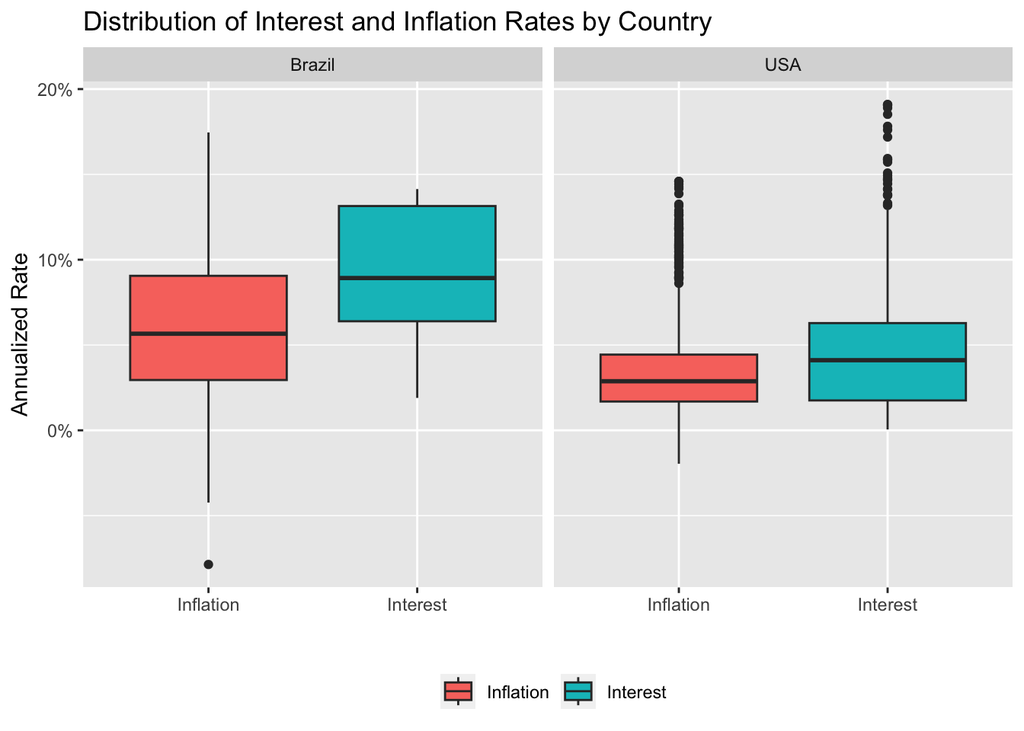

- The boxplot is used to compare the distribution of the inflation and interest rates, among each other, and among the countries.
- Brazil:
  - The inflation and interest rates in Brazil have a similar dispersion.
  - The interest rates in Brazil are left skewed.
  - The median of the interest rates is significantly larger than the median of inflation rates.
- US:
  - The inflation rates are less dispersed than the interest rates.
  - The median of the interest and inflation rate is not that different.
  - We have many outliers for both inflation and interest rates.
- US x Brazil:
  - Both inflation and interest rates in Brazil have a greater dispersion than in US.
  - Also, the both rates in Brazil have a higher median than in US.

## Descriptive Statistics

```
##  Interest Rates US Inflation Rates US
##  Min.   :0.00050   Min.   :-0.01959
##  1st Qu.:0.01752   1st Qu.: 0.01688
##  Median :0.04110   Median : 0.02877
##  Mean   :0.04595   Mean   : 0.03583
##  3rd Qu.:0.06285   3rd Qu.: 0.04438
##  Max.   :0.19100   Max.   : 0.14592
```

```
##  Interest Rates BR Inflation Rates BR
##  Min.   :0.01900   Min.   :-0.07862
##  1st Qu.:0.06392   1st Qu.: 0.02949
##  Median :0.08925   Median : 0.05662
##  Mean   :0.08940   Mean   : 0.05834
##  3rd Qu.:0.13145   3rd Qu.: 0.09055
##  Max.   :0.14140   Max.   : 0.17459
```

## Rates over Time

### US

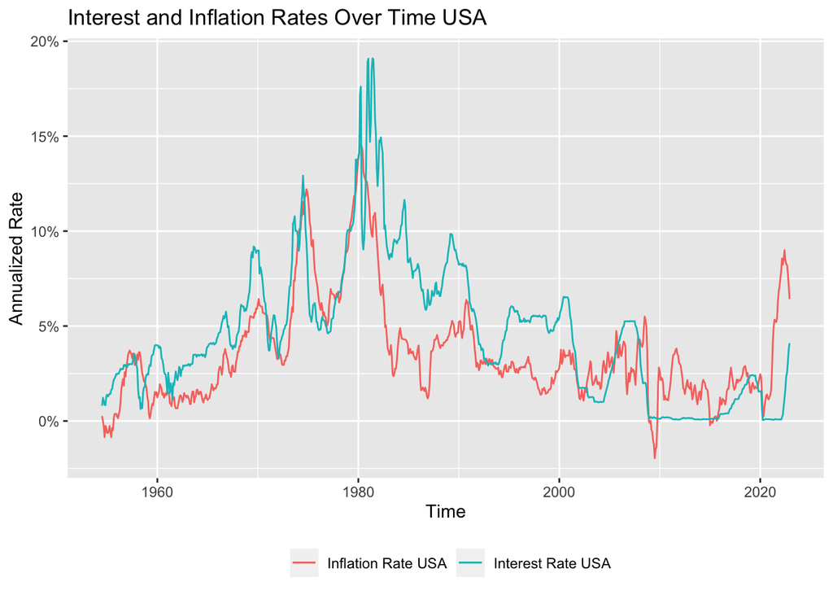

- We can see that for US, both rates were increasing until 1980.
- Then they started to decline until 2020.
- After 2020 the rates started to increase again.
- Both rates have been moving in the same direction over the years, so they may be positively associated.
- There was a long period 2010 and 2015, where we had very close to 0% interest rates.

### Brazil

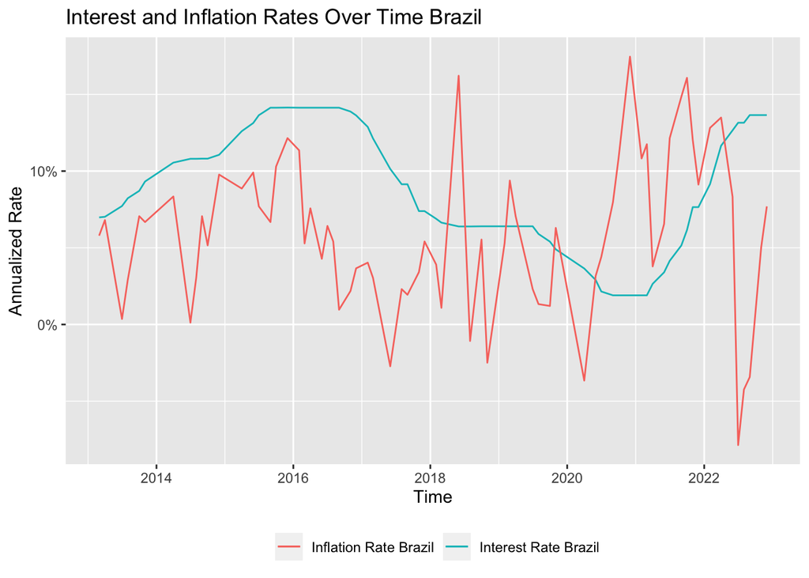

- Pertaining to Brazil, we have significantly less recorded data. Therefore, it is difficult to draw any conclusions.
- For Brazil, we cannot conclude that there is a relationship between interest and inflation rates.

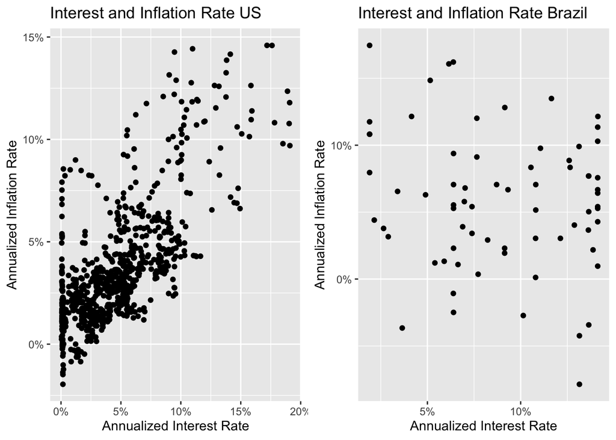

- We can see that the interest and inflation rate are positively associated in US, but there is no clear relationship between them in Brazil.

## Analyzing Outliers

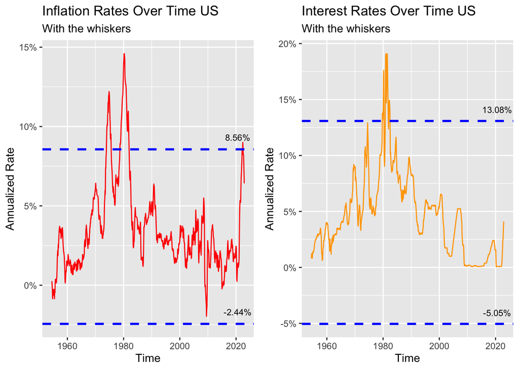

## Conclusion

[figure not shown]